# Data Import and Submission Export Tutorial

#### This tutorial will use R to import the data and output a sample submission.

To begin, make sure your R session has its working directory set to the same directory where your data is located. To view your current working directory, run the command `getwd()` in the R console. Use the R options `File -> Change dir...` in the RGui to set your working directory or use the `setwd('insert/your/path/to/data.csv')` command to set your working directory.

To double check that `train.csv` and `test.csv` are in your current working directory, the following command should return `TRUE` twice, as seen in the output below.

```r
c('train.csv', 'test.csv') %in% list.files()
```

1. TRUE

2. TRUE

## Data Import

Now that we have an R session with our two data files in the working directory, read the comma separated data using the `read.csv()` function and view a few predictor summaries.

```r
train = read.csv('train.csv')
```

```r
head(train)
```

|  | RowID | CalendarYear | ModelYear | Make | Model | Cat1 | Cat2 | Cat3 | Cat4 | Cat5 | ⋯ | Var5 | Var6 | Var7 | Var8 | NVCat | NVVar1 | NVVar2 | NVVar3 | NVVar4 | Response |
| --- | --- | --- | --- | --- | --- | --- | --- | --- | --- | --- | --- | --- | --- | --- | --- | --- | --- | --- | --- | --- | --- |
| 1 | 418079 | 2005 | 2004 | AU | AU.14 | B | C | A | A | A |  | 0.02168622 | -0.6852558 | -0.5912954 | -0.2584976 | F | -0.2315299 | -0.2661168 | 4.209404 | -0.2514189 | 0 |
| 2 | 232625 | 2006 | 2003 | R | R.30 | B | C | B | A | A |  | -0.3529838 | -0.4232408 | -0.6281582 | 0.05436843 | O | -0.2315299 | -0.2661168 | -0.2723372 | -0.2514189 | 0 |
| 3 | 379029 | 2006 | 2006 | AU | AU.14 | B | A | A | A | A |  | 0.06926337 | -0.6852558 | -0.5912954 | -0.163872 | M | -0.2315299 | -0.2661168 | -0.2723372 | -0.2514189 | 1 |
| 4 | 181458 | 2007 | 2000 | BU | BU.38 | F | C | A | C | A |  | 0.0871048 | -0.1717531 | -0.9722114 | 0.2064257 | O | -0.2315299 | -0.2661168 | -0.2723372 | -0.2514189 | 0 |
| 5 | 192434 | 2005 | 1999 | BU | BU.38 | F | A | A | C | A |  | 0.0871048 | -0.2723481 | -0.9722114 | 0.290987 | M | -0.2315299 | -0.2661168 | -0.2723372 | -0.2514189 | 1 |
| 6 | 443321 | 2007 | 2005 | AU | AU.11 | B | C | B | A | A |  | 0.1406291 | -0.1635651 | -0.5421449 | 0.5499219 | O | -0.2315299 | -0.2661168 | -0.2723372 | -0.2514189 | 0 |

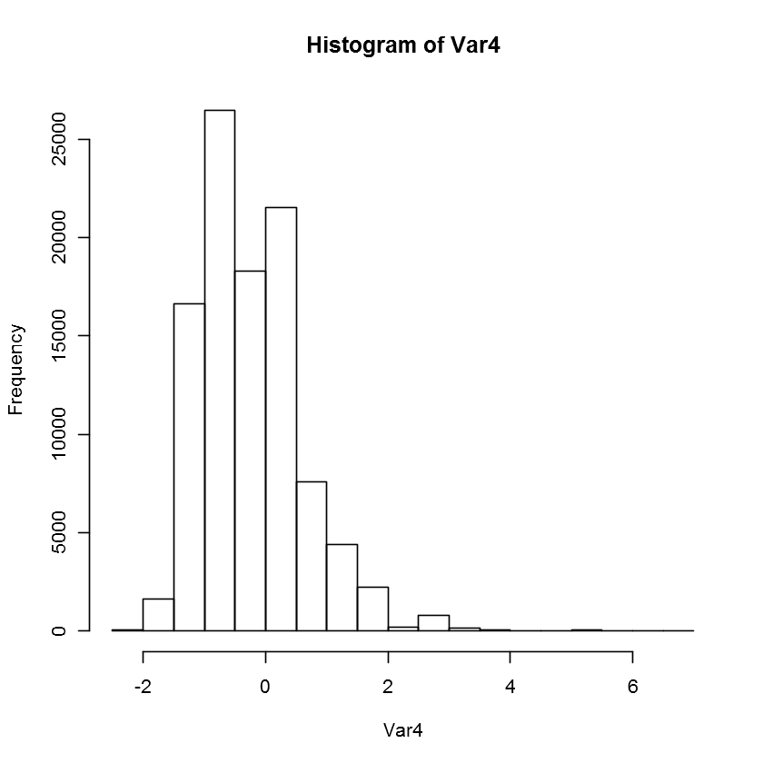

```r
hist(train$Var4, main = "Histogram of Var4", xlab = "Var4")
```

```r
summary(train$Var8)
```

```
    Min.  1st Qu.   Median     Mean  3rd Qu.     Max.
-1.48500 -0.52320 -0.24210 -0.00946  0.16210 33.90000
```

Also read the test set into your R session via the `read.csv()` function.

```r
test = read.csv('test.csv')
```

```r
head(test)
```

|  | RowID | CalendarYear | ModelYear | Make | Model | Cat1 | Cat2 | Cat3 | Cat4 | Cat5 | ⋯ | Var4 | Var5 | Var6 | Var7 | Var8 | NVCat | NVVar1 | NVVar2 | NVVar3 | NVVar4 |
| --- | --- | --- | --- | --- | --- | --- | --- | --- | --- | --- | --- | --- | --- | --- | --- | --- | --- | --- | --- | --- | --- |
| 1 | 491169 | 2009 | 2006 | AN | AN.4 | B | B | B | A | A |  | -0.9014148 | -0.7871253 | -0.939083 | -0.8124724 | -0.7338132 | J | -0.2315299 | 2.021183 | -0.2723372 | 1.408637 |
| 2 | 661907 | 2009 | 2001 | BU | BU.5 | B | C | B | A | A |  | 1.043661 | 0.3963563 | 0.004873184 | -0.82476 | 0.808638 | O | -0.2315299 | -0.2661168 | -0.2723372 | -0.2514189 |
| 3 | 489459 | 2009 | 2005 | Y | Y.21 | B | C | A | A | A |  | -0.7830189 | -0.6443939 | -0.8408273 | -0.6895963 | -0.8164055 | E | -0.2315299 | -0.2661168 | -0.2723372 | -0.2514189 |
| 4 | 496824 | 2009 | 2006 | BF | BF.18 | B | C | A | A | A |  | 0.9929196 | 0.5331406 | 0.2493426 | -0.5544326 | 0.01006398 | O | -0.2315299 | -0.2661168 | -0.2723372 | -0.2514189 |
| 5 | 464567 | 2009 | 2008 | K | K.40 | E | C | A | A | A |  | -1.104379 | -1.179637 | -1.061903 | -0.1366537 | -0.616215 | O | -0.2315299 | -0.2661168 | -0.2723372 | -0.2514189 |
| 6 | 307296 | 2009 | 2007 | K | K.40 | E | C | A | A | A |  | -1.104379 | -1.179637 | -1.061903 | -0.2595298 | -0.685133 | L | -0.2315299 | -0.2661168 | -0.2723372 | -0.2514189 |

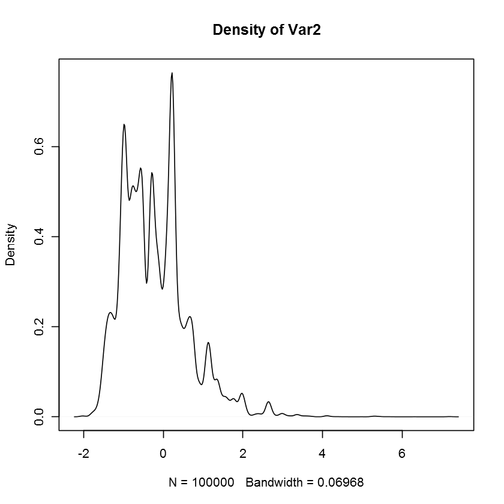

```r
plot(density(train$Var2), main = "Density of Var2")
```

```r
dim(train)
```

1. 100000

2. 32

```r
dim(test)
```

1. 40000

2. 31

The training and testing sets have a different number of columns. This is, of course, because the test set does not contain the response variable. The following command will tell us which column is contained in the training set and not in the testing set.

```r
setdiff(names(train), names(test))
```

"Response"

## Data Export

When making a submission, the predictions need to be exported in a certain fashion. The example below will generate random uniform numbers and use them as our predictions.

```r
numberOfObservationsInTestSet = nrow(test)
vectorOfPredictions = runif(numberOfObservationsInTestSet, 0, 1)
summary(vectorOfPredictions)
```

```
     Min.   1st Qu.    Median      Mean   3rd Qu.      Max.
0.0000013 0.2508000 0.4968000 0.4987000 0.7473000 0.9999000
```

```r
outputDataSet = data.frame("RowID" = test$RowID,
                           "ProbabilityOfResponse" = vectorOfPredictions)
```

Inspect data set before export

```r
head(outputDataSet)
```

|  | RowID | ProbabilityOfResponse |
| --- | --- | --- |
| 1 | 491169 | 0.5298258 |
| 2 | 661907 | 0.7990218 |
| 3 | 489459 | 0.42184 |
| 4 | 496824 | 0.7455896 |
| 5 | 464567 | 0.1310719 |
| 6 | 307296 | 0.8185932 |

The following command will output a comma separated file to the current working directory. Find your current working directory again by executing the `getwd()` command.

```r
write.csv(outputDataSet, "submissionExample.csv", row.names = FALSE)
```